# Patient-Generated Health Data as a Predictor of Adverse Outcomes in Veterans

## Figure 5. XGBoost Feature Importance: Steps + Static Model

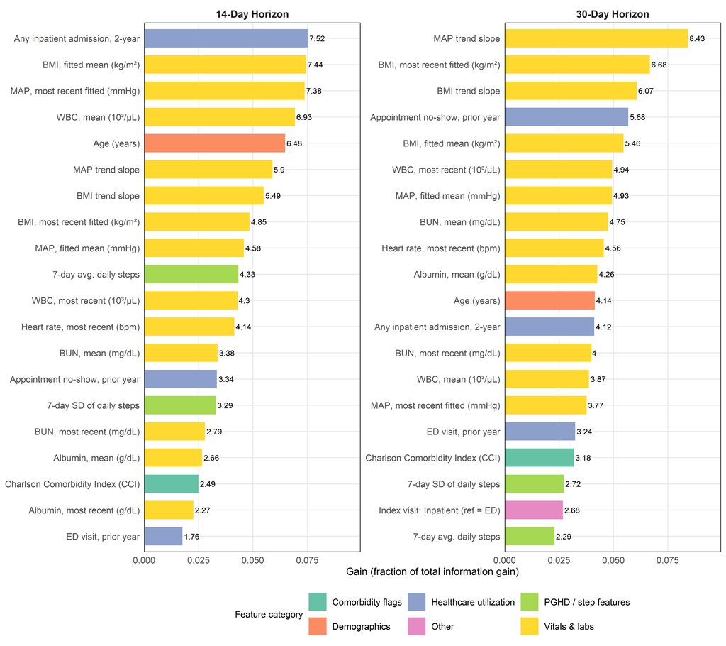

Figure 5. Top 20 XGBoost feature importances (Gain): Steps + Static, 14-Day and 30-Day Horizons. Bars filled by feature category (colorblind-friendly Set2 palette). Gain = fractional contribution to total information gain across all trees. Labels show Gain x 100.

## Figure 6. Logistic Regression Coefficients: Steps + Static Model

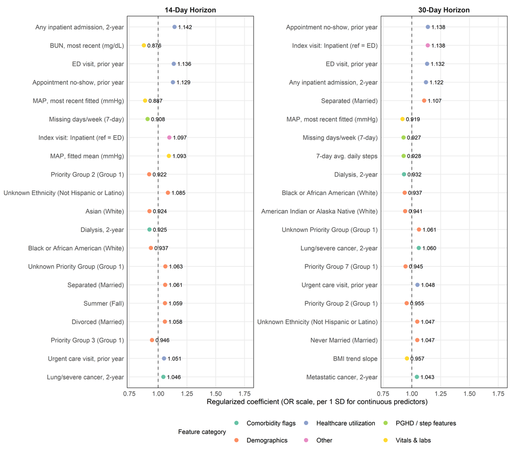

Figure 6. Top 20 elastic net-regularized logistic regression coefficients (OR scale, per 1 SD for continuous predictors): Steps + Static, 14-Day and 30-Day Horizons. Colored by feature category (Set2 palette). These are penalized estimates and should be interpreted as directional associations reflecting relative feature importance within the model, not formal hypothesis tests.

*Note: Coefficients are elastic net-penalized estimates (glmnet, Steps + Static model). Penalization shrinks estimates toward zero and the plot carries no inferential standard errors or significance thresholds; values reflect the direction and relative magnitude of each feature’s contribution within the regularized model. A full coefficient table is saved to `logistic_coefficients_14d_30d.xlsx`.*

*Analysis completed: 2026-05-29 16:25*  
*Seed: 2026 | R version: R version 4.5.0 (2025-04-11 ucrt)*